# Формирование модели монетизации игрового приложения

Основная задача исследования - на основании данных об активностях пользователей игры «Космические братья» попытаться утвердить или скорректировать имеющуюся модель монетизации (показ рекламы при выборе типа постройки), или предложить новую.  
Также, проанализируем данные о рекламных компаниях, и сделаем выводы об их эффективности.

Навигация:

- Описание и задачи
- Загрузка библиотек и датасетов
- Предобработка данных
- Создание профилей пользователей
- Анализ профилей пользователей
  - Распределение количества построек
  - Зависимость количества построек от вовлеченности
- Анализ рекламной компании
- Выводы и рекомендации

## Загрузка библиотек и датасетов

к навигации

Импортируем необходимые библиотеки.

```python
import pandas as pd
import numpy as np

import matplotlib
import matplotlib.pyplot as plt
import seaborn as sns

from scipy import stats as st
```

Установим параметры визуализации.

```python
#%config InlineBackend.figure_format = 'retina'
matplotlib.style.use('bmh')
```

Загрузим данные и ознакомимся с ними.

```python
local_path = r'C:\Практикум\Учебные проекты\15 Выпускной проект\\'
cloud_path = r'Путь к облачному хранилищу'

def get_data(file_name):
    try:
        data = pd.read_csv(local_path + file_name)
        print('Датасет {0} загружен локально.'.format(file_name))
    except:
        data = pd.read_csv(cloud_path + file_name)
        print('Датасет {0} загружен из облака.'.format(file_name))
    return data

actions = get_data('game_actions.csv')
sources = get_data('user_source.csv')
costs = get_data('ad_costs.csv')
```

```
Датасет game_actions.csv загружен локально.
Датасет user_source.csv загружен локально.
Датасет ad_costs.csv загружен локально.
```

```python
#actions.info()
#actions.head()
```

```python
#sources.info()
#sources.head()
```

```python
#costs.info()
#costs.head()
```

## Предобработка данных

к навигации

Проверим датафреймы на ниличие дубликатов.

```python
for dataset in [actions, sources, costs]:
    print(dataset.duplicated().sum())
```

```
1
0
0
```

Удалим дубликат в таблице 'actions'.

```python
actions = actions.drop_duplicates()
#actions.info()
```

Изменим тип данных в полях 'event_datetime' датафрейма 'actions' и 'day' таблицы 'costs' с текстового на datetime.

```python
actions['event_datetime'] = pd.to_datetime(actions['event_datetime'])
#actions.dtypes
```

```python
costs['day'] = pd.to_datetime(costs['day'])
#costs.dtypes
```

Заполним заглушками пропуски в датафрейме 'actions'.

```python
actions = actions.fillna('none')
#actions.info()
```

В ходе предобработки найден и удален дубликат, изменен тип данных в двух столбцах, пропуски заполнены заглушками.

## Создание профилей пользователей

к навигации

Создадим таблицу 'users', добавив к датафрейму 'sources' данные о дате первой активности и времени, прошедшего с момента последней активности (в часах).

```python
lifetime = actions.groupby('user_id', as_index=False).agg({'event_datetime': ['min', 'max']})
lifetime.columns = lifetime.columns.droplevel()
lifetime = lifetime.rename(columns={'': 'user_id', 'min': 'first_action_dt', 'max': 'last_action_dt'})
# группируем данные, убираем лишний уровень заголовка столбцов, переименовываем столбцы

max_dt = actions['event_datetime'].max()
# выясняем, когда зафиксировано самое последнее действие в игре

lifetime['last_action_hrs'] = ((max_dt - lifetime['last_action_dt']).dt.total_seconds() / 3600).astype('int')
lifetime['first_action_dt'] = lifetime['first_action_dt'].dt.date
lifetime['first_action_dt'] = pd.to_datetime(lifetime['first_action_dt'])
lifetime = lifetime.drop(columns='last_action_dt')
# оставляем только дату в столбце 'first_action_dt' и убираем более не нужный столбец 'last_action_dt'

users = sources.merge(lifetime, on='user_id')
users.info()
users.head()
```

```
<class 'pandas.core.frame.DataFrame'>
Int64Index: 13576 entries, 0 to 13575
Data columns (total 4 columns):
 #   Column           Non-Null Count  Dtype
---  ------           --------------  -----
 0   user_id          13576 non-null  object
 1   source           13576 non-null  object
 2   first_action_dt  13576 non-null  datetime64[ns]
 3   last_action_hrs  13576 non-null  int32
dtypes: datetime64[ns](1), int32(1), object(2)
memory usage: 477.3+ KB
```

|  | user_id | source | first_action_dt | last_action_hrs |
| --- | --- | --- | --- | --- |
| 0 | 0001f83c-c6ac-4621-b7f0-8a28b283ac30 | facebook_ads | 2020-05-06 | 385 |
| 1 | 00151b4f-ba38-44a8-a650-d7cf130a0105 | yandex_direct | 2020-05-06 | 433 |
| 2 | 001aaea6-3d14-43f1-8ca8-7f48820f17aa | youtube_channel_reklama | 2020-05-05 | 531 |
| 3 | 001d39dc-366c-4021-9604-6a3b9ff01e25 | instagram_new_adverts | 2020-05-05 | 580 |
| 4 | 002f508f-67b6-479f-814b-b05f00d4e995 | facebook_ads | 2020-05-05 | 345 |

Разобъем игроков на категории:  
0 - не прошедший уровень.  
1 - "воин", прошедший уровень без постройки проекта;  
2 - "конструктор", построивший проект;

Добавим эти данные к профилям пользователей.

```python
levelupped_players = actions.query('event == "finished_stage_1"') \
                            .merge(actions.query('event == "project"'),
                                   on='user_id',
                                   how='outer') \
                            [['user_id', 'event_x', 'event_y']]

levelupped_players = levelupped_players.fillna(1) \
                                       .rename(columns={'event_y': 'player_type'}) \
                                       .replace({'project': 2}) \
                                       [['user_id', 'player_type']]

users = users.merge(levelupped_players, on='user_id', how='left')
users = users.fillna(0)
#users.info()
#users.head()
```

Посчитаем количество зданий, построенных игроками и добавим результат к таблице 'users'.

```python
building_counts = actions.pivot_table(index='user_id',
                                      columns='building_type',
                                      values='event_datetime',
                                      aggfunc='count') \
                         .fillna(0) \
                         .drop(columns='none')

building_counts['total_bildings'] = building_counts['assembly_shop'] \
                                  + building_counts['research_center'] \
                                  + building_counts['spaceport']

users = users.merge(building_counts, on='user_id')
```

Добавим к профилям среднее время, прошедшее между активностями.

```python
actions_sorted = actions.sort_values(by=['user_id', 'event_datetime'])
actions_sorted['next_event_dt'] = actions_sorted.groupby(['user_id'])['event_datetime'].shift(periods=-1)
actions_sorted['event_delta'] = ((actions_sorted['next_event_dt'] - actions_sorted['event_datetime']) \
                                .dropna() \
                                .dt.total_seconds() / 3600).astype('int')
event_delta = round(actions_sorted.groupby('user_id', as_index=False)['event_delta'].mean())
users = users.merge(event_delta, on='user_id')
```

```python
users.info()
users.head()
```

```
<class 'pandas.core.frame.DataFrame'>
Int64Index: 13576 entries, 0 to 13575
Data columns (total 10 columns):
 #   Column           Non-Null Count  Dtype
---  ------           --------------  -----
 0   user_id          13576 non-null  object
 1   source           13576 non-null  object
 2   first_action_dt  13576 non-null  datetime64[ns]
 3   last_action_hrs  13576 non-null  int32
 4   player_type      13576 non-null  float64
 5   assembly_shop    13576 non-null  float64
 6   research_center  13576 non-null  float64
 7   spaceport        13576 non-null  float64
 8   total_bildings   13576 non-null  float64
 9   event_delta      13519 non-null  float64
dtypes: datetime64[ns](1), float64(6), int32(1), object(2)
memory usage: 1.1+ MB
```

|  | user_id | source | first_action_dt | last_action_hrs | player_type | assembly_shop | research_center | spaceport | total_bildings | event_delta |
| --- | --- | --- | --- | --- | --- | --- | --- | --- | --- | --- |
| 0 | 0001f83c-c6ac-4621-b7f0-8a28b283ac30 | facebook_ads | 2020-05-06 | 385 | 0.0 | 6.0 | 1.0 | 6.0 | 13.0 | 28.0 |
| 1 | 00151b4f-ba38-44a8-a650-d7cf130a0105 | yandex_direct | 2020-05-06 | 433 | 0.0 | 4.0 | 0.0 | 5.0 | 9.0 | 36.0 |
| 2 | 001aaea6-3d14-43f1-8ca8-7f48820f17aa | youtube_channel_reklama | 2020-05-05 | 531 | 0.0 | 2.0 | 0.0 | 2.0 | 4.0 | 69.0 |
| 3 | 001d39dc-366c-4021-9604-6a3b9ff01e25 | instagram_new_adverts | 2020-05-05 | 580 | 1.0 | 4.0 | 0.0 | 4.0 | 8.0 | 19.0 |
| 4 | 002f508f-67b6-479f-814b-b05f00d4e995 | facebook_ads | 2020-05-05 | 345 | 0.0 | 3.0 | 1.0 | 8.0 | 12.0 | 35.0 |

На данном этапе нами был создан датафрейм с данными об игроках, включающий информацию:

1. об источнике привлечения;
2. дате первой активности;
3. времени, прошедшем с последней активности;
4. количестве построек (по типам и суммарном);
5. среднем временем между активностями.

## Анализ профилей пользователей

к навигации

Определим количество и долю игроков по типам.

```python
users_cnt = users.groupby('player_type').count()
users_cnt['percentage'] = round(users_cnt['user_id'] / len(users) * 100, 1).astype('str') + "%"
users_cnt = users_cnt.rename(columns={'user_id': 'cnt'})[['cnt', 'percentage']]
users_cnt
```

| player_type | cnt | percentage |
| --- | --- | --- |
| 0.0 | 7759 | 57.2% |
| 1.0 | 3951 | 29.1% |
| 2.0 | 1866 | 13.7% |

Чуть меньше половины игроков перешли на новый уровень. Из них, треть - построив проект.

Определим статус игроков, не перешедших на следующий уровень (продолжает ли пользователь играть): найдем максимальное для 95% пользователей значение временного промежутка между действиями игроков, и установим его в качестве порогового. Если игрок не появлялся в игре дольше порогового значения, скорее всего, он перестал играть: посмотрим на соотношение играющих и бросивших игру пользователей.

```python
actions_sorted = actions.sort_values(by=['user_id', 'event_datetime'])
actions_sorted['next_event_dt'] = actions_sorted.groupby(['user_id'])['event_datetime'].shift(periods=-1)
actions_sorted['event_delta'] = ((actions_sorted['next_event_dt'] - actions_sorted['event_datetime']) \
                                .dropna() \
                                .dt.total_seconds() / 3600).astype('int') \
                                .round()

np.percentile(actions_sorted['event_delta'].dropna(), [95])
```

```
array([88.])
```

Для подавляющего большинства пользователей временные промежутки между действиями в игре не превышают 88 часов.

```python
len(users.query('player_type == 0 and last_action_hrs <= 88'))
```

```
3
```

Среди игроков, не прошедших уровень, с вероятностью 95%, играют только 3 человека. Этим количеством можно пренебречь, и считать всех таких пользователей отвалившимися.

Посмотрим, как коррелируют значения профилей между собой.

```python
users.corr()
```

|  | last_action_hrs | player_type | assembly_shop | research_center | spaceport | total_bildings | event_delta |
| --- | --- | --- | --- | --- | --- | --- | --- |
| last_action_hrs | 1.000000 | -0.245775 | 0.060168 | -0.367916 | -0.605371 | -0.466490 | -0.189217 |
| player_type | -0.245775 | 1.000000 | 0.188214 | 0.278220 | 0.212074 | 0.316633 | -0.262606 |
| assembly_shop | 0.060168 | 0.188214 | 1.000000 | 0.292723 | 0.011206 | 0.613295 | -0.544661 |
| research_center | -0.367916 | 0.278220 | 0.292723 | 1.000000 | 0.348068 | 0.673894 | -0.353335 |
| spaceport | -0.605371 | 0.212074 | 0.011206 | 0.348068 | 1.000000 | 0.750218 | -0.284781 |
| total_bildings | -0.466490 | 0.316633 | 0.613295 | 0.673894 | 0.750218 | 1.000000 | -0.573535 |
| event_delta | -0.189217 | -0.262606 | -0.544661 | -0.353335 | -0.284781 | -0.573535 | 1.000000 |

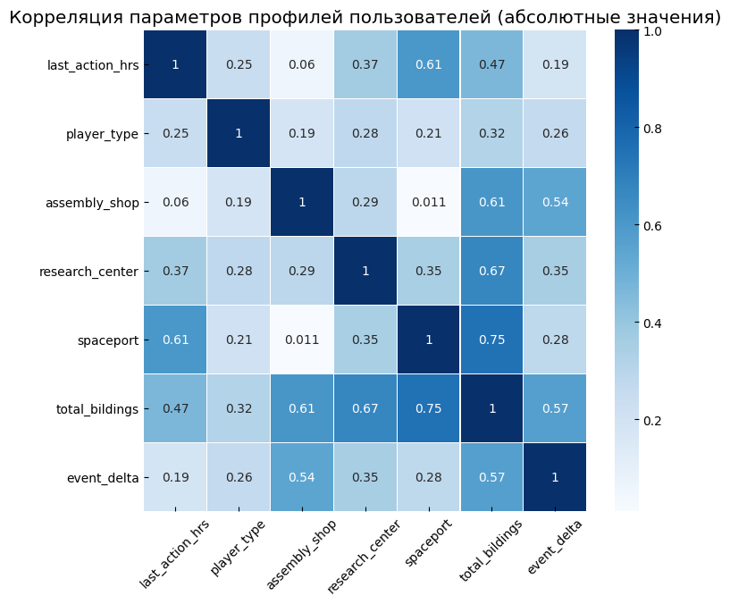

```python
fig, ax = plt.subplots(figsize=(8,7))
sns.heatmap(users.corr().abs(), annot=True, linewidth=.1, cmap='Blues') \
   .set(title="Корреляция параметров профилей пользователей (абсолютные значения)")
plt.xticks(rotation=45)
plt.show()
```

Количество зданий сильней коррелирует с временем между активностими, нежели с типом игрока. Ниже разберем обе эти закономерности. Но сначала переименуем типы игроков, т.к. числовые значения были нужны только для понимания корреляций.

```python
users['player_type'] = users['player_type'].astype('str') \
                                           .replace({'0.0': 'none', '1.0': 'warrior', '2.0': 'constructor'})
```

Мы установили доли пользователей, переставших играть, прошедших уровень, и сделавших это, построив проект.  
Также, обнаружили, что количество построек коррелирует с другими параметрами, но сильнее - с временем между активностями.

### Анализ распределения количества построек

к навигации

Посмотрим на распределение количества построенных зданий среди всех пользователей.

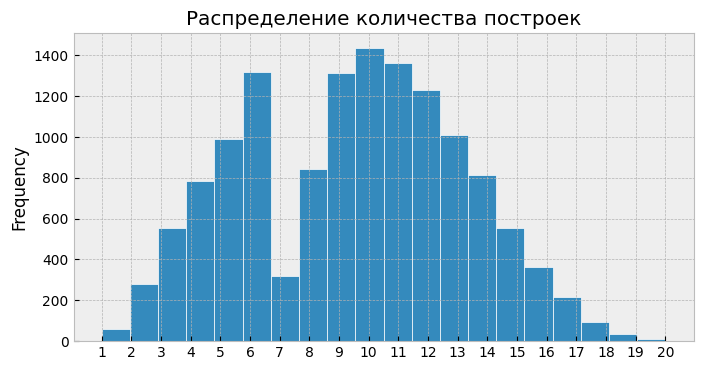

```python
bildings_max = users['total_bildings'].max().astype('int')
bildings_min = users['total_bildings'].min().astype('int')
bins = bildings_max - bildings_min + 1
users['total_bildings'].plot(kind='hist',
                             bins=bins,
                             figsize=(8, 4),
                             title="Распределение количества построек",
                             xticks=np.arange(bildings_min, bildings_max + 1),
                             rot=0,
                             edgecolor='white');
```

Видим подозрительный провал в районе 7-ми зданий. Посмотрим на распределение с разбивкой по типам игроков.

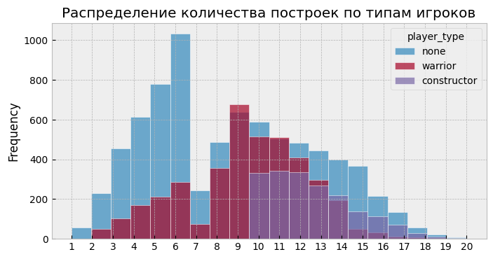

```python
users.pivot_table(index='user_id',
                  columns='player_type',
                  values='total_bildings')[['none', 'warrior', 'constructor']] \
     .plot(kind='hist',
           bins=bins,
           figsize=(8, 4),
           title="Распределение количества построек по типам игроков",
           xticks=np.arange(bildings_min, bildings_max + 1),
           rot=0,
           alpha=0.7,
           edgecolor='white');
```

Для конструкторов 10 - минимальное число зданий. Возможно, это является условием для создания проекта.  
Для других групп - провал в районе семерки.  
Построим для них гистограммы по с разбивкой по каналам привлечения.

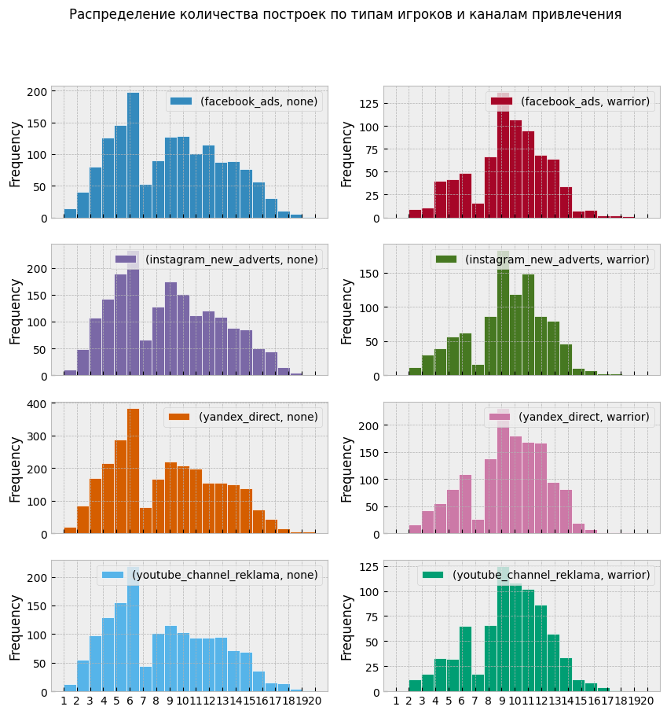

```python
users.query('player_type != "constructor"') \
     .pivot_table(index='user_id',
                  columns=['source','player_type'],
                  values='total_bildings') \
     .plot(kind='hist',
           bins=bins,
           figsize=(10, 10),
           title="Распределение количества построек по типам игроков и каналам привлечения",
           xticks=np.arange(bildings_min, bildings_max + 1),
           subplots=True,
           layout=(4, 2),
           edgecolor='white');
```

Распределение не зависит от канала привлечения. Вероятно, после постройки шестого здания игрокам надоедает строительство, и/или появляется возможность полноценно воевать.

Посмотрим на количество построенных зданий (минимальное, медианное и максимальное) с разбивкой по типу игроков и (отдельно) каналам привлечения.  
Определим функцию для построения графика.

```python
def draw_a_plot(dimension, function, xlabel, func_label, dimension_label):

    users.groupby(dimension)[['assembly_shop', 'research_center', 'spaceport', 'total_bildings']] \
         .agg(function) \
         .plot(figsize=(9, 4),
               kind='bar',
               grid=True,
               title=(func_label + ' количество построенных зданий \n с разбивкой по ' + dimension_label),
               xlabel=xlabel,
               ylabel='Количество зданий',
               rot=0);
```

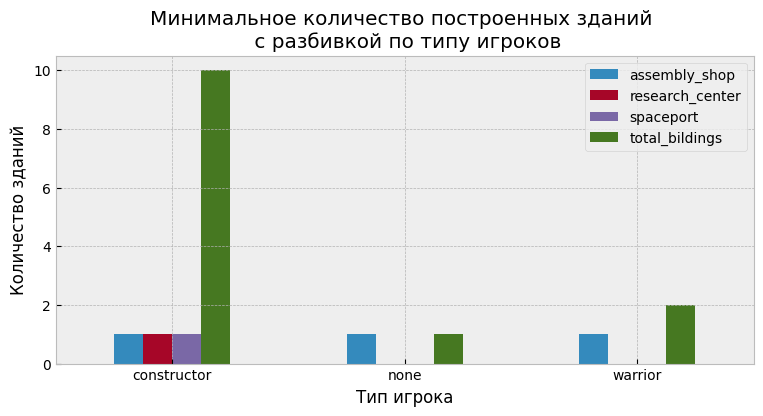

```python
draw_a_plot('player_type', 'min', 'Тип игрока', 'Минимальное', 'типу игроков')
```

Конструкторы строят минимум 10 строений (что мы уже знали), и, как минимум, по одному строению каждого вида. Вероятно, это является условием для создания проекта.  
Минимальное количество построек воинов - 2, причем одно из них - сборочный цех (наверное - первое доступное строение).

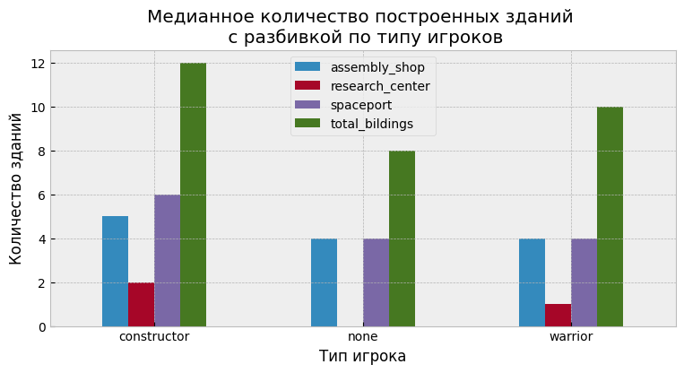

```python
draw_a_plot('player_type', 'median', 'Тип игрока', 'Медианное', 'типу игроков')
```

Исследовательский центр - наименее популярное строение. Возможно, разработчикам стоит обратить на это внимание. Конструкторы в среднем строят 2 таких здания, воины - одно, а остальные пользователи исследовательский центр строят очень редко.  
Также, конструкторы в среднем строят на 2 строения больше воинов, и на 4 - остальных игроков.

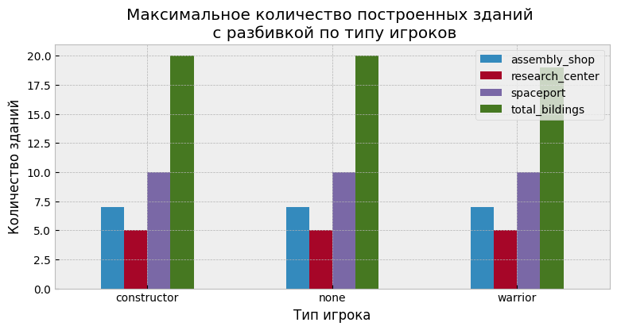

```python
draw_a_plot('player_type', 'max', 'Тип игрока', 'Максимальное', 'типу игроков')
```

Максимальное количество зданий не зависит от типа игрока.

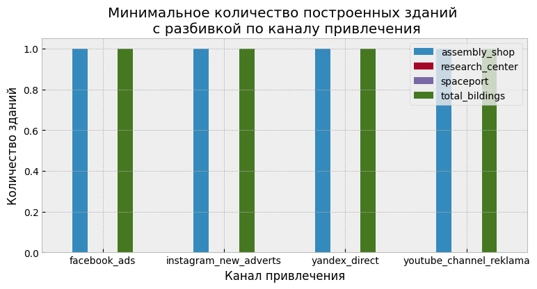

```python
draw_a_plot('source', 'min', 'Канал привлечения', 'Минимальное', 'каналу привлечения')
```

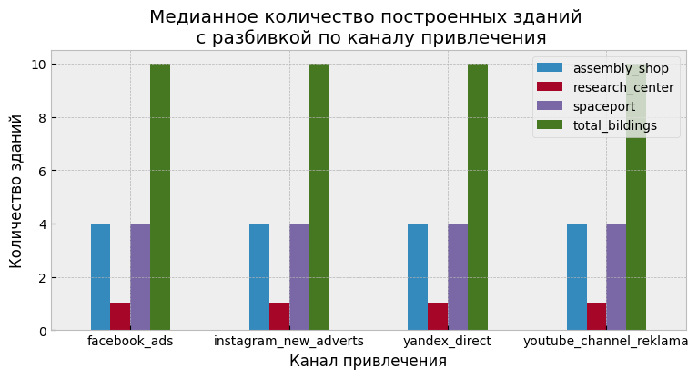

```python
draw_a_plot('source', 'median', 'Канал привлечения', 'Медианное', 'каналу привлечения')
```

Канал привлечения никак не влияет на минимальное и медианное количество зданий.

Проанализировав распределение количества построек по типам игроков и каналов привлечения, мы установили ряд как ожидаемых (строители - строят), так и неожиданных закономерностей.  
Отсутствие влияния канала привлечения пригодится при анализе рекламной компании.

### Зависимость количества построек от вовлеченности в игру

к навигации

Время между активностями, очевидно, отражает степень вовлеченности пользователя в игру. Как мы помним, количество построенных зданий и время между активностями коррелируют сильнее прочих параметров.  
Построим график, иллюстрирующий эту зависимость.

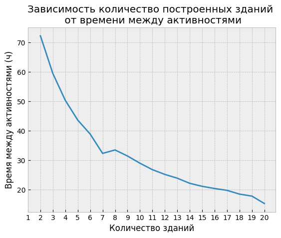

```python
users.groupby('total_bildings')['event_delta'] \
         .agg('mean') \
         .plot(grid=True,
               xticks=np.arange(bildings_min, bildings_max + 1),
               title=('Зависимость количество построенных зданий \n от времени между активностями'),
               xlabel='Количество зданий',
               ylabel='Время между активностями (ч)',
               rot=0);
```

График показателен, но он не учитывает количества игроков.  
Найдем медианное значение времени между активностями и проверим гипотезу:  
H0: Количество зданий, построенных игроками, совершающими активности чаще медианнго значение времени между активностями НЕ отличается от количества зданий, построенных игроками, совершающими активности реже этого значения. Тогда...  
H1: Количество зданий, построенных игроками, совершающими активности чаще медианнго значение времени между активностями отличается от количества зданий, построенных игроками, совершающими активности реже этого значения.

Сформируем совокупности.

```python
median_event_delta = users['event_delta'].median()
o_bildings_cnt = users.query('event_delta < @median_event_delta')['total_bildings']
p_bildings_cnt = users.query('event_delta > @median_event_delta')['total_bildings']
print("Размеры совокупностей:", len(o_bildings_cnt), "и", len(p_bildings_cnt))
```

```
Размеры совокупностей: 6566 и 6499
```

Размеры совокупностей практически равны, используем параметр equal_var=True.

```python
r = st.ttest_ind(o_bildings_cnt, p_bildings_cnt, equal_var=True)
alpha = 0.05
text = """Статистика разности равна {0:.5f}.
Вероятность получить такой результат случайно: {1:.10f}%.""" \
             .format(abs(r[0]), r.pvalue * 100)
print(text)
if r.pvalue < alpha:
    print('Отвергаем нулевую гипотезу.')
else:
    print('Не получилось отвергнуть нулевую гипотезу.')
```

```
Статистика разности равна 66.51869.
Вероятность получить такой результат случайно: 0.0000000000%.
Отвергаем нулевую гипотезу.
```

Количество зданий отличается. Посмотрим - на сколько.

```python
print('Медианное количество зданий для строящих часто: {0:.1f}, строящих редко: {1:.1f}'
     .format(o_bildings_cnt.median(), p_bildings_cnt.median()))
```

```
Медианное количество зданий для строящих часто: 12.0, строящих редко: 7.0
```

Как видим, значения довольно сильно различаются, что мы смогли подтвердить статистически.  
Сравним выборки по типу игроков.

```python
users.query('event_delta < @median_event_delta') \
     .groupby('player_type', as_index=False)['user_id'] \
     .count() \
     .merge(users.query('event_delta > @median_event_delta') \
                 .groupby('player_type', as_index=False)['user_id'] \
                 .count(), on='player_type') \
     .rename(columns={'user_id_x': 'fast_players_cnt', 'user_id_y': 'slow_players_cnt'})
```

|  | player_type | fast_players_cnt | slow_players_cnt |
| --- | --- | --- | --- |
| 0 | constructor | 1403 | 407 |
| 1 | none | 3151 | 4312 |
| 2 | warrior | 2012 | 1780 |

Три четверти конструкторов строят быстро. Воины распределены примерно поровну. Остальных в полтора раза болше в группе медленных строителей.

## Анализ рекламной компании

к навигации

Посмотрим на стоимость одного гипотетического показа рекламы с разбивкой по источнику.

```python
channels = costs.groupby('source', as_index=False)['cost'].sum() \
                .merge(users.groupby('source', as_index=False)['total_bildings'].sum())
channels['bilding_cost'] = channels['cost'] / channels['total_bildings']
```

```python
channels
```

|  | source | cost | total_bildings | bilding_cost |
| --- | --- | --- | --- | --- |
| 0 | facebook_ads | 2140.904643 | 26131.0 | 0.081930 |
| 1 | instagram_new_adverts | 2161.441691 | 31815.0 | 0.067938 |
| 2 | yandex_direct | 2233.111449 | 45032.0 | 0.049589 |
| 3 | youtube_channel_reklama | 1068.119204 | 24978.0 | 0.042762 |

Стоимость одной постройки для игроков, пришедших из Youtube и Yandex почти в два раза меньше, чем из Facebook.

Посчитаем долю игроков разного типа по каналам привлечения.

```python
pt_by_source = users.pivot_table(index='source', columns='player_type', values='user_id', aggfunc='count')
pt_by_source['total_players'] = pt_by_source.sum(axis=1)
round(pt_by_source.div(pt_by_source['total_players'], axis=0) * 100)
```

| player_type source | constructor | none | warrior | total_players |
| --- | --- | --- | --- | --- |
| facebook_ads | 14.0 | 58.0 | 28.0 | 100.0 |
| instagram_new_adverts | 14.0 | 56.0 | 30.0 | 100.0 |
| yandex_direct | 13.0 | 58.0 | 30.0 | 100.0 |
| youtube_channel_reklama | 14.0 | 57.0 | 29.0 | 100.0 |

Доли практически совпадают.

Посчитаем стоимость привлечения одного игрока.

```python
pt_by_source.reset_index()
channels = channels.merge(pt_by_source['total_players'], on='source')
channels['player_cost'] = channels['cost'] / channels['total_players']
channels
```

|  | source | cost | total_bildings | bilding_cost | total_players | player_cost |
| --- | --- | --- | --- | --- | --- | --- |
| 0 | facebook_ads | 2140.904643 | 26131.0 | 0.081930 | 2726 | 0.785365 |
| 1 | instagram_new_adverts | 2161.441691 | 31815.0 | 0.067938 | 3347 | 0.645785 |
| 2 | yandex_direct | 2233.111449 | 45032.0 | 0.049589 | 4817 | 0.463590 |
| 3 | youtube_channel_reklama | 1068.119204 | 24978.0 | 0.042762 | 2686 | 0.397662 |

Картина та же, что и в случае со стоимостью одной активности.

Рассчитаем стоимость привлечения пользователя и добавим ее к таблице с профилями.

```python
costs['day'] = costs['day'] + pd.Timedelta("1 day")
cac = users.groupby(['source', 'first_action_dt'], as_index=False)['user_id'].count() \
           .rename(columns={'user_id': 'users_cnt',
                            'first_action_dt': 'day'}) \
           .merge(costs, on=['source', 'day'], how='outer')

cac['cac'] = round(cac['cost'] / cac['users_cnt'], 3)
cac = cac.rename(columns={'day': 'first_action_dt'})
users = users.merge(cac, on=['source', 'first_action_dt'])
users = users.drop(columns=['users_cnt', 'cost'])
#users.info()
#users.head()
```

Добавим к профилям дату каждой активности.

```python
actions['event_datetime'] = actions['event_datetime'].dt.date
actions['event_datetime'] = pd.to_datetime(actions['event_datetime'])
users = users.merge(actions[['user_id', 'event_datetime']], on='user_id', how='left')
users['lifetime'] = (users['event_datetime'] - users['first_action_dt']).dt.days
#users.info()
#users.head()
```

Определим функцию расчета LTV и ROI

```python
def get_metrics(users, dimensions=[]):

    revenue = users.pivot_table(index=dimensions,
                                columns='lifetime',
                                values='total_bildings',
                                aggfunc='sum')
    revenue = revenue.fillna(0).cumsum(axis=1)
    cohort_sizes = users.groupby(dimensions, as_index=False)['user_id'].nunique() \
                        .rename(columns={'user_id': 'cohort_size'})
    revenue = cohort_sizes.merge(revenue, on=dimensions, how='left').fillna(0)
    revenue = revenue.set_index(dimensions)

    ltv = revenue.div(revenue['cohort_size'], axis=0)
    ltv = ltv.drop(columns=['cohort_size'])

    cac = users[['user_id', 'cac'] + dimensions]
    cac = cac.groupby(dimensions).mean()

    roi = cac.merge(ltv, left_index=True, right_index=True)
    roi = roi.div(roi['cac'], axis=0).drop(columns=['cac'])

    return ltv, roi
```

Получим значения метрик и их динамики.

```python
ltv, roi = get_metrics(users, ['source'])
ltv_dynamics, roi_dynamics = get_metrics(users, ['source', 'event_datetime'])
```

Построим графики LTV, ROI и их динамики.

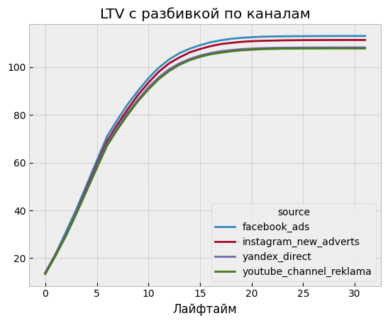

```python
ltv.T.plot(grid=True, title=('LTV с разбивкой по каналам'), xlabel='Лайфтайм');
```

Графики накопления количества активностей (потенциальных показов рекламы) не сильно разнятся по каналам привлечения.

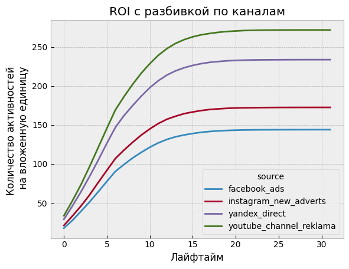

```python
roi.T.plot(grid=True,
           title=('ROI с разбивкой по каналам'),
           xlabel='Лайфтайм',
           ylabel='Количество активностей \n на вложенную единицу');
```

А вот возврат инвестиций заметно отличается. Хотя, этот вывод можно было сделать уже на основании данных, полученных до этого.

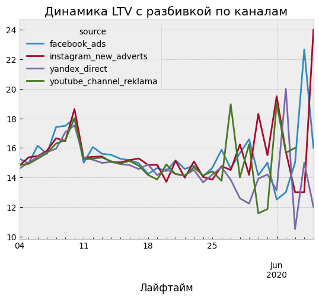

```python
columns = [name for name in ltv_dynamics.index.names if name not in ['event_datetime']]
ltv_dynamics.pivot_table(index='event_datetime',
                         columns=columns,
                         values=31,
                         aggfunc='mean') \
            .plot(grid=True,
                  title=('Динамика LTV с разбивкой по каналам'),
                  xlabel='Лайфтайм');
```

Значения растут в дни рекламных компаний и падают после их окончания. С 11-го по 25-й день игры наблюдается относительное плато.  
Флуктуации после 25-го дня, вероятно, проявление того, что кто-то прошел уровень, и о них нет данных, а кто-то перестал играть.

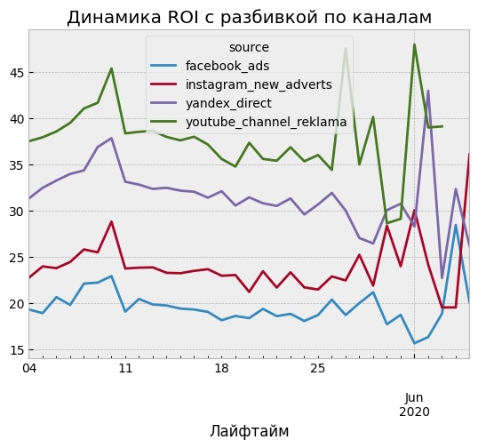

```python
columns = [name for name in ltv_dynamics.index.names if name not in ['event_datetime']]
roi_dynamics.pivot_table(index='event_datetime',
                         columns=columns,
                         values=31,
                         aggfunc='mean') \
            .plot(grid=True,
                  title=('Динамика ROI с разбивкой по каналам'),
                  xlabel='Лайфтайм');
```

Графики соответствуют графику динамики LTV с поправкой на стоимость привлечения. Ничего нового мы не увидели.

Все каналы привлекли практически идентичных по своим характеристикам пользователей.  
Но заметно отличающаяся стоимость рекламных компаний приводит к соответствующим показателям возврата инвестиций.

## Общие выводы и рекомендации

к навигации

Анализ данных не позволяет точно предсказать поведение игрока, так что, одна из возможных стратегий монетизации - рискованная: начинаем показывать рекламу начиная с первой постройки, и надеемся, что она не слишком отпугнет пользователей.

Второй вариант монетизации - осторожный. Первые 6 построек, вероятно, - критическое число для удержания игрока. Показ рекламы начиная с первой активности может быть негативно воспринят пользователем, что скажется на итоговом количестве просмотров. Поэтому - начинаем показывать рекламу, начиная с седьмой постройки.

Сильнее всего на количество построек (и, соответственно - просмотров рекламы) влияет среднее время между активностями (чем чаще строят, тем больше построят).  
Поэтому, рекомендуемая стратегия - адаптивная. Начиная со второй активности начинаем показывать рекламу слабо вовлеченным (строящим реже чем раз в 28 часов) игрокам. Велика вероятность, что такие пользователи принесут мало просмотров в перспективе - риск отпугнуть их рекламой оправдан. После каждой постройки пересчитываем среднее время между активностями и делаем корректировку относительно показа/не показа. И так до 7-го строения. Начиная с седьмого - показываем при каждой активности (игрок уже втянулся).

В связи с тем, что канал привлечения пользователей никак не влияет на их качество, следует направить рекламный бюджет в канал(ы) с наименьшей стоимостью привлечения. На данный момент это - Ютьюб_Реклама и Яндекс_Директ.

```python
#writer = pd.ExcelWriter('/home/ww/Анализ данных/Учебные проекты/Итоговый проект/users.xlsx')
#users.to_excel(writer)
#writer.save()
#writer.close()
```

Презентация: https://disk.yandex.ru/i/CaZI3HTRpHtf8g  
Дашборд: https://datalens.yandex/txfmsl2t1n6ci?tab=wP